# 13 - Anotación génica y análisis de sobrerrepresentación (ORA) en TCGA-SKCM

Sonia Salmerón Fructuoso

2026-11-03

# 1 Objetivo

En este script se completa la anotación de los genes identificados en el screening Cox transcriptómico (script 11) y se realiza un **análisis de sobrerrepresentación (ORA)** para interpretar funcionalmente los genes asociados a la supervivencia en melanoma cutáneo.

Los pasos son:

1. Cargar los resultados del screening Cox (`cox_transcriptome_results.csv`).
2. Convertir identificadores Ensembl a símbolo génico y Entrez ID usando `org.Hs.eg.db`.
3. Generar un volcano plot (log HR vs -log10 FDR).
4. Realizar ORA sobre los genes con FDR < 0,05 usando GO-BP y `clusterProfiler`.
5. Exportar la tabla anotada y los resultados funcionales.

# 2 1. Paquetes

```r
cran_pkgs <- c("ggplot2", "dplyr", "tibble", "ggrepel", "readr")
for (p in cran_pkgs)
  if (!requireNamespace(p, quietly = TRUE)) install.packages(p)

bioc_pkgs <- c("clusterProfiler", "org.Hs.eg.db", "enrichplot")
for (p in bioc_pkgs) {
  if (!requireNamespace(p, quietly = TRUE)) {
    if (!requireNamespace("BiocManager", quietly = TRUE))
      install.packages("BiocManager")
    BiocManager::install(p, ask = FALSE, update = FALSE)
  }
}

library(ggplot2)
library(tibble)
library(ggrepel)
library(readr)
library(clusterProfiler)
library(org.Hs.eg.db)
library(enrichplot)
# dplyr al final para que sus funciones tengan prioridad sobre AnnotationDbi::select/filter
library(dplyr)
```

# 3 2. Carga de resultados del screening Cox

```r
cox_res <- read_csv("results/cox_transcriptome_results.csv", show_col_types = FALSE)

# Excluir las variables clínicas que se colaron en el CSV
cox_genes <- cox_res %>%
  filter(grepl("^ENSG", gene))

dim(cox_genes)
```

```
## [1] 5000    4
```

```r
head(cox_genes)
```

```
## # A tibble: 6 × 4
##   gene                  HR    pvalue      FDR
##   <chr>              <dbl>     <dbl>    <dbl>
## 1 ENSG00000107165.13 1.05  0.0000262 0.000363
## 2 ENSG00000129824.16 1.02  0.125     0.251
## 3 ENSG00000186081.12 1.07  0.0000409 0.000502
## 4 ENSG00000122133.17 1.06  0.000103  0.000981
## 5 ENSG00000197172.10 0.976 0.0963    0.209
## 6 ENSG00000221867.9  0.972 0.0642    0.154
```

# 4 3. Anotación Ensembl → SYMBOL y ENTREZID

Los identificadores del CSV incluyen el número de versión (e.g., `ENSG00000162645.13`). Se elimina la versión antes de mapear con `org.Hs.eg.db`.

```r
# Eliminar versión del identificador Ensembl
cox_genes <- cox_genes %>%
  mutate(ensembl_clean = sub("\\..*", "", gene))

# Mapeo Ensembl → SYMBOL
map_symbol <- mapIds(
  org.Hs.eg.db,
  keys    = cox_genes$ensembl_clean,
  column  = "SYMBOL",
  keytype = "ENSEMBL",
  multiVals = "first"
)

# Mapeo Ensembl → ENTREZID
map_entrez <- mapIds(
  org.Hs.eg.db,
  keys    = cox_genes$ensembl_clean,
  column  = "ENTREZID",
  keytype = "ENSEMBL",
  multiVals = "first"
)

cox_genes <- cox_genes %>%
  mutate(
    SYMBOL   = map_symbol[ensembl_clean],
    ENTREZID = map_entrez[ensembl_clean]
  )

# Resumen de cobertura
n_total    <- nrow(cox_genes)
n_symbol   <- sum(!is.na(cox_genes$SYMBOL))
n_entrez   <- sum(!is.na(cox_genes$ENTREZID))

cat("Genes totales:", n_total, "\n")
```

```
## Genes totales: 5000
```

```r
cat("Con símbolo génico:", n_symbol, "(", round(100*n_symbol/n_total), "%)\n")
```

```
## Con símbolo génico: 4524 ( 90 %)
```

```r
cat("Con Entrez ID:", n_entrez, "(", round(100*n_entrez/n_total), "%)\n")
```

```
## Con Entrez ID: 4524 ( 90 %)
```

## 4.1 Top 20 genes anotados por FDR

```r
cox_genes %>%
  arrange(FDR) %>%
  dplyr::select(SYMBOL, HR, pvalue, FDR, ENTREZID) %>%
  head(20)
```

```
## # A tibble: 20 × 5
##    SYMBOL      HR   pvalue         FDR ENTREZID
##    <chr>    <dbl>    <dbl>       <dbl> <chr>
##  1 GBP2     0.775 4.15e-11 0.000000207 2634
##  2 GBP4     0.834 5.60e-10 0.00000112  115361
##  3 TAF5LP1  0.816 1.06e- 9 0.00000112  645744
##  4 IL15     0.793 8.54e-10 0.00000112  3600
##  5 GIMAP2   0.763 1.19e- 9 0.00000112  26157
##  6 DDX60    0.750 1.34e- 9 0.00000112  55601
##  7 <NA>     0.825 2.38e- 9 0.00000135  <NA>
##  8 KLRD1    0.823 2.21e- 9 0.00000135  3824
##  9 CCL8     0.827 2.42e- 9 0.00000135  6355
## 10 GCNT1    0.775 3.34e- 9 0.00000167  2650
## 11 NCCRP1   1.14  5.04e- 9 0.00000180  342897
## 12 <NA>     0.854 4.20e- 9 0.00000180  <NA>
## 13 APOBEC3G 0.789 5.36e- 9 0.00000180  60489
## 14 UBA7     0.774 5.30e- 9 0.00000180  7318
## 15 <NA>     0.728 5.39e- 9 0.00000180  <NA>
## 16 CXCL11   0.860 7.10e- 9 0.00000220  6373
## 17 GBP5     0.861 7.91e- 9 0.00000220  115362
## 18 CLEC2B   0.753 7.63e- 9 0.00000220  9976
## 19 ZNF831   0.854 8.58e- 9 0.00000226  128611
## 20 GBP1     0.834 1.03e- 8 0.00000258  2633
```

# 5 4. Volcano plot (log HR vs -log10 FDR)

Adaptación del volcano plot estándar de expresión diferencial al contexto Cox: el eje X muestra el log(HR), que indica la dirección del efecto (protector si log HR < 0, de riesgo si log HR > 0); el eje Y muestra -log10(FDR).

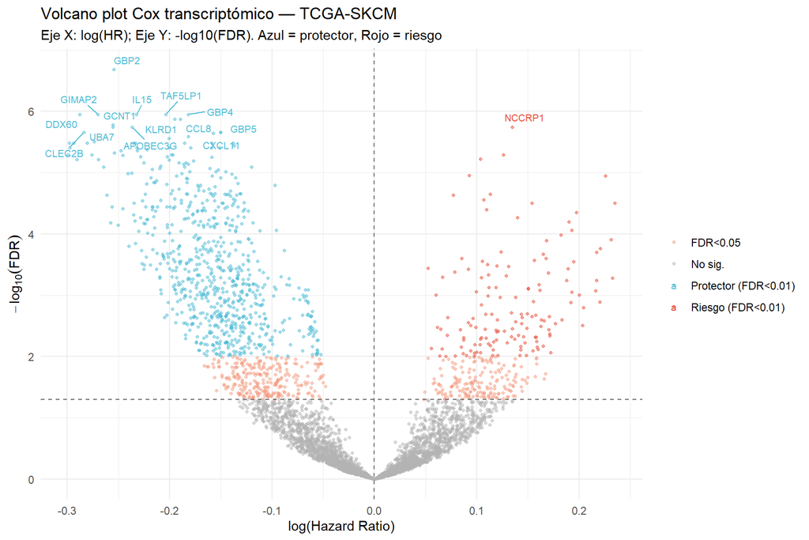

```r
vol_df <- cox_genes %>%
  filter(!is.na(SYMBOL)) %>%
  mutate(
    logHR = log(HR),
    neg_log_FDR = -log10(FDR),
    categoria = case_when(
      FDR < 0.01 & logHR < 0  ~ "Protector (FDR<0.01)",
      FDR < 0.01 & logHR > 0  ~ "Riesgo (FDR<0.01)",
      FDR < 0.05               ~ "FDR<0.05",
      TRUE                     ~ "No sig."
    )
  )

# Etiquetar los 15 genes con menor FDR entre los que tienen símbolo génico (vol_df excluye los NA);
# incluye pseudogenes (p. ej. TAF5LP1), por lo que no coincide con el top 15 literal del ranking.
top_label <- vol_df %>%
  filter(FDR < 0.001) %>%
  arrange(FDR) %>%
  slice_head(n = 15)

ggplot(vol_df, aes(logHR, neg_log_FDR, color = categoria)) +
  geom_point(alpha = 0.5, size = 0.9) +
  geom_text_repel(
    data = top_label,
    aes(label = SYMBOL),
    size = 2.8, max.overlaps = 20
  ) +
  scale_color_manual(values = c(
    "Protector (FDR<0.01)" = "#4DBBD5",
    "Riesgo (FDR<0.01)"    = "#E64B35",
    "FDR<0.05"             = "#F39B7F",
    "No sig."              = "grey70"
  )) +
  geom_vline(xintercept = 0, linetype = "dashed", color = "grey40") +
  geom_hline(yintercept = -log10(0.05), linetype = "dashed", color = "grey40") +
  labs(
    title = "Volcano plot Cox transcriptómico — TCGA-SKCM",
    subtitle = "Eje X: log(HR); Eje Y: -log10(FDR). Azul = protector, Rojo = riesgo",
    x = "log(Hazard Ratio)",
    y = expression(-log[10](FDR)),
    color = NULL
  ) +
  theme_minimal(base_size = 11)
```

```r
# Guardar figura
ggsave("figures/volcano_cox_transcriptomico.png",
       width = 9, height = 6, dpi = 300)
```

# 6 5. Análisis de sobrerrepresentación (ORA)

Se realiza ORA sobre los genes con FDR < 0,05, separando genes protectores (HR < 1) y genes de riesgo (HR > 1) para facilitar la interpretación biológica.

## 6.1 5.1 Preparación de listas génicas

```r
# Genes con FDR < 0.05 y con Entrez ID válido
sig_genes <- cox_genes %>%
  filter(FDR < 0.05, !is.na(ENTREZID))

protectores <- sig_genes %>% filter(HR < 1) %>% pull(ENTREZID) %>% unique()
riesgo      <- sig_genes %>% filter(HR > 1) %>% pull(ENTREZID) %>% unique()
universo    <- cox_genes %>% filter(!is.na(ENTREZID)) %>% pull(ENTREZID) %>% unique()

cat("Genes protectores (FDR<0.05, HR<1):", length(protectores), "\n")
```

```
## Genes protectores (FDR<0.05, HR<1): 1011
```

```r
cat("Genes de riesgo  (FDR<0.05, HR>1):", length(riesgo), "\n")
```

```
## Genes de riesgo  (FDR<0.05, HR>1): 323
```

```r
cat("Universo (genes testados con Entrez):", length(universo), "\n")
```

```
## Universo (genes testados con Entrez): 4522
```

## 6.2 5.2 ORA — genes protectores (alta expresión asociada a mejor supervivencia)

```r
set.seed(42)
ora_prot <- enrichGO(
  gene          = protectores,
  universe      = universo,
  OrgDb         = org.Hs.eg.db,
  keyType       = "ENTREZID",
  ont           = "BP",
  pAdjustMethod = "BH",
  pvalueCutoff  = 0.05,
  qvalueCutoff  = 0.20,
  readable      = TRUE
)

ora_prot_df <- as.data.frame(ora_prot)
cat("Términos GO-BP significativos (protectores):", nrow(ora_prot_df), "\n")
```

```
## Términos GO-BP significativos (protectores): 571
```

```r
if (nrow(ora_prot_df) > 0) {
  ora_prot_df %>%
    dplyr::select(ID, Description, GeneRatio, BgRatio, p.adjust, Count) %>%
    mutate(p.adjust = formatC(p.adjust, format = "e", digits = 2)) %>%
    head(15)
}
```

```
##                    ID                                  Description GeneRatio
## GO:0002250 GO:0002250                     adaptive immune response   207/887
## GO:0050776 GO:0050776                regulation of immune response   241/887
## GO:0002684 GO:0002684 positive regulation of immune system process   261/887
## GO:0046649 GO:0046649                        lymphocyte activation   216/887
## GO:0045321 GO:0045321                         leukocyte activation   242/887
## GO:0050778 GO:0050778       positive regulation of immune response   198/887
## GO:0001775 GO:0001775                              cell activation   253/887
## GO:0098542 GO:0098542           defense response to other organism   228/887
## GO:0002252 GO:0002252                      immune effector process   191/887
## GO:0140546 GO:0140546                 defense response to symbiont   203/887
## GO:0051249 GO:0051249          regulation of lymphocyte activation   152/887
## GO:0002694 GO:0002694           regulation of leukocyte activation   165/887
## GO:0042110 GO:0042110                            T cell activation   165/887
## GO:0045087 GO:0045087                       innate immune response   188/887
## GO:0002443 GO:0002443                  leukocyte mediated immunity   145/887
##             BgRatio p.adjust Count
## GO:0002250 279/3757 1.33e-74   207
## GO:0050776 358/3757 2.12e-74   241
## GO:0002684 422/3757 1.72e-69   261
## GO:0046649 326/3757 6.76e-64   216
## GO:0045321 391/3757 7.16e-64   242
## GO:0050778 287/3757 1.10e-62   198
## GO:0001775 446/3757 2.42e-56   253
## GO:0098542 390/3757 3.41e-53   228
## GO:0002252 300/3757 1.03e-51   191
## GO:0140546 340/3757 1.06e-48   203
## GO:0051249 217/3757 2.50e-48   152
## GO:0002694 248/3757 5.12e-48   165
## GO:0042110 248/3757 5.12e-48   165
## GO:0045087 306/3757 1.77e-47   188
## GO:0002443 204/3757 2.57e-47   145
```

## 6.3 5.3 ORA — genes de riesgo (alta expresión asociada a peor supervivencia)

```r
set.seed(42)
ora_risk <- enrichGO(
  gene          = riesgo,
  universe      = universo,
  OrgDb         = org.Hs.eg.db,
  keyType       = "ENTREZID",
  ont           = "BP",
  pAdjustMethod = "BH",
  pvalueCutoff  = 0.05,
  qvalueCutoff  = 0.20,
  readable      = TRUE
)

ora_risk_df <- as.data.frame(ora_risk)
cat("Términos GO-BP significativos (riesgo):", nrow(ora_risk_df), "\n")
```

```
## Términos GO-BP significativos (riesgo): 15
```

```r
if (nrow(ora_risk_df) > 0) {
  ora_risk_df %>%
    dplyr::select(ID, Description, GeneRatio, BgRatio, p.adjust, Count) %>%
    mutate(p.adjust = formatC(p.adjust, format = "e", digits = 2)) %>%
    head(15)
}
```

```
##                    ID                                     Description GeneRatio
## GO:0031424 GO:0031424                                  keratinization     8/276
## GO:0008544 GO:0008544                           epidermis development    25/276
## GO:0043588 GO:0043588                                skin development    22/276
## GO:0009913 GO:0009913                  epidermal cell differentiation    17/276
## GO:0030216 GO:0030216                    keratinocyte differentiation    13/276
## GO:0043473 GO:0043473                                    pigmentation    11/276
## GO:0046148 GO:0046148                    pigment biosynthetic process     8/276
## GO:0042440 GO:0042440                       pigment metabolic process     9/276
## GO:0045109 GO:0045109              intermediate filament organization     6/276
## GO:0006582 GO:0006582                       melanin metabolic process     7/276
## GO:0042438 GO:0042438                    melanin biosynthetic process     7/276
## GO:0044550 GO:0044550       secondary metabolite biosynthetic process     7/276
## GO:0060429 GO:0060429                          epithelium development    47/276
## GO:0045104 GO:0045104 intermediate filament cytoskeleton organization     7/276
## GO:0045103 GO:0045103             intermediate filament-based process     7/276
##             BgRatio p.adjust Count
## GO:0031424  12/3757 7.61e-04     8
## GO:0008544 119/3757 1.21e-03    25
## GO:0043588 104/3757 3.06e-03    22
## GO:0009913  68/3757 3.06e-03    17
## GO:0030216  44/3757 4.64e-03    13
## GO:0043473  33/3757 5.35e-03    11
## GO:0046148  18/3757 5.79e-03     8
## GO:0042440  23/3757 5.79e-03     9
## GO:0045109  10/3757 7.00e-03     6
## GO:0006582  15/3757 8.58e-03     7
## GO:0042438  15/3757 8.58e-03     7
## GO:0044550  15/3757 8.58e-03     7
## GO:0060429 361/3757 8.58e-03    47
## GO:0045104  17/3757 2.03e-02     7
## GO:0045103  18/3757 2.91e-02     7
```

## 6.4 5.4 Visualización — dotplot genes protectores

```r
if (nrow(ora_prot_df) > 0) {
  dotplot(ora_prot, showCategory = 15) +
    labs(title = "ORA GO-BP — genes protectores (TCGA-SKCM)") +
    theme(axis.text.y = element_text(size = 9))
  ggsave("figures/ora_go_protectores.png", width = 9, height = 7, dpi = 300)
}
```

## 6.5 5.5 Visualización — dotplot genes de riesgo

```r
if (nrow(ora_risk_df) > 0) {
  dotplot(ora_risk, showCategory = 15) +
    labs(title = "ORA GO-BP — genes de riesgo (TCGA-SKCM)") +
    theme(axis.text.y = element_text(size = 9))
  ggsave("figures/ora_go_riesgo.png", width = 9, height = 7, dpi = 300)
}
```

# 7 6. Exportación de resultados

```r
# Tabla completa anotada
write_csv(cox_genes, "results/cox_transcriptome_results_annotated.csv")

# ORA protectores
if (nrow(ora_prot_df) > 0)
  write_csv(ora_prot_df, "results/ora_go_protectores.csv")

# ORA riesgo
if (nrow(ora_risk_df) > 0)
  write_csv(ora_risk_df, "results/ora_go_riesgo.csv")

cat("Exportación completada.\n")
```

```
## Exportación completada.
```

# 8 Interpretación

Los resultados del ORA constituyen la base para la selección de genes candidatos para firmas multigénicas y para la discusión biológica del TFM.